# Presentation

12-5-2021

## Introduction

## Study

**Sanctuary et al., 2019:** Pilot study of probiotic/colostrum supplementation on gut function in children with autism and gastrointestinal symptoms

- Prebiotic (Bovine Milk Oligosaccharides) or synbiotic (BMO + *B. infantis*) treatment
- Autism symptoms
- Gastrointestinal symptoms
- Metabolites from fecal, urine, and serum samples
- Immune cell populations in blood
- Microbiota of fecal samples

## Data

Study design:

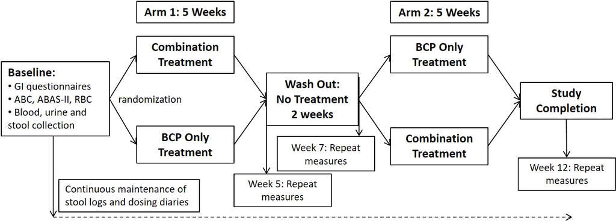

## Data

Excel file with six sheets:

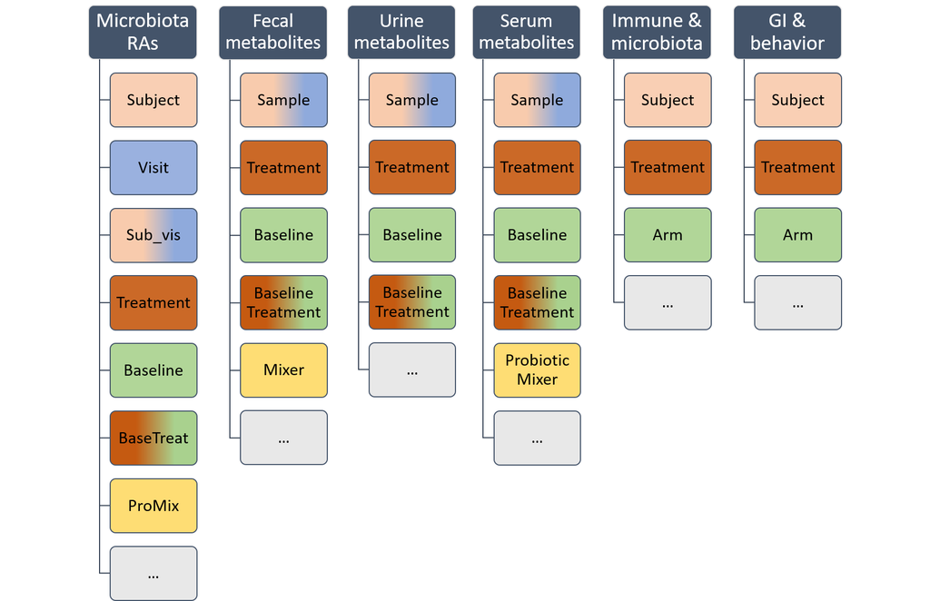

## Methods

## Tidying data

- Align column names
- Change entries with typos
- Assign NAs
- Remove undesired and empty columns
- Filter out redundancy

## Tidying data

immune_microbiota data issue:

```
## # A tibble: 16 x 5
##    Subject Treatment   Arm IL13_CD4_Pre IL13_CD4_Post
##      <dbl> <chr>     <dbl>        <dbl>         <dbl>
##  1     202 Pre           1         3.57          1.41
##  2     205 Pre           1         1.97          2.9
##  3     208 Pre           1        NA            NA
##  4     210 Pre           1         0.7           1.13
##  5     204 Pre           2         7.11          1.68
##  6     207 Pre           2         2.89          1.88
##  7     211 Pre           2         7.75          2.59
##  8     212 Pre           2         3.98          3.86
##  9     204 Syn           1         4.02          1.74
## 10     207 Syn           1         3.25          1.45
## 11     211 Syn           1         4.17          2.75
## 12     212 Syn           1         3.48          3.27
## 13     202 Syn           2         2.68          1.41
## 14     205 Syn           2         2.87          0.9
## 15     208 Syn           2        NA            NA
## 16     210 Syn           2         0.9           0.76
```

## Tidying data

GI_behavior data issue:

```
## # A tibble: 16 x 6
##    Subject Treatment   Arm Order Stool_Freq_Pre Stool_Norm_Pre
##      <dbl> <chr>     <dbl> <chr>          <dbl>          <dbl>
##  1     202 Pre           1 PS            NA             NA
##  2     202 Syn           2 PS            NA             NA
##  3     204 Pre           2 SP            NA             NA
##  4     204 Syn           1 SP            NA             NA
##  5     205 Pre           1 PS            NA             NA
##  6     205 Syn           2 PS            NA             NA
##  7     207 Pre           2 SP             3.47           0
##  8     207 Syn           1 SP             4.75           0
##  9     208 Pre           1 PS            NA             NA
## 10     208 Syn           2 PS             0.333          0.75
## 11     210 Pre           1 PS             0.857          0.4
## 12     210 Syn           2 PS             0.824          0.357
## 13     211 Pre           2 SP             0.810          0.294
## 14     211 Syn           1 SP             0.769          0.5
## 15     212 Pre           2 SP             1.4            0.286
## 16     212 Syn           1 SP             1.21           0.294
```

## Tidying data

Data from stool log excluded:

```
## spec_tbl_df[,24] [16 × 24] (S3: spec_tbl_df/tbl_df/tbl/data.frame)
##  $ Subject        : num [1:16] 202 202 204 204 205 205 207 207 208 208 ...
##  $ Treatment      : chr [1:16] "Pre" "Syn" "Pre" "Syn" ...
##  $ Arm            : num [1:16] 1 2 2 1 1 2 2 1 1 2 ...
##  $ Order          : chr [1:16] "PS" "PS" "SP" "SP" ...
##  $ Stool_Freq_Pre : num [1:16] NA NA NA NA NA ...
##  $ Stool_Norm_Pre : num [1:16] NA NA NA NA NA NA 0 0 NA 0.75 ...
##  $ Stool_Hard_Pre : num [1:16] NA NA NA NA NA ...
##  $ Stool_Soft_Pre : num [1:16] NA NA NA NA NA ...
##  $ Stool_Freq_D123: num [1:16] 0.667 0.667 0 1 2 ...
##  $ Stool_Freq_W1  : num [1:16] 0.571 0.286 0.571 0.714 2.143 ...
##  $ Stool_Freq_W5  : num [1:16] 0.5 0.286 1 1 2.143 ...
##  $ Stool_Freq_D835: num [1:16] 0.368 0.227 1.091 0.789 2.182 ...
##  $ Stool_Norm_D123: num [1:16] 0 0 NA 0 0.2 0.4 0 0 0 NA ...
##  $ Stool_Norm_W1  : num [1:16] 0 0 0 0.2 0.214 ...
##  $ Stool_Norm_W5  : num [1:16] 0.5 0 0.571 0.667 0.6 ...
##  $ Stool_Norm_D835: num [1:16] 0.286 0.1 0.833 0.2 0.429 ...
##  $ Stool_Hard_D123: num [1:16] 1 1 NA 0 0.2 0.4 0 0 0 NA ...
##  $ Stool_Hard_W1  : num [1:16] 1 1 0.75 0 0.286 ...
##  $ Stool_Hard_W5  : num [1:16] 0.5 0.8 0.143 0 0.133 ...
##  $ Stool_Hard_D835: num [1:16] 0.1111 0.5714 0.0385 0.381 0.1692 ...
##  $ Stool_Soft_D123: num [1:16] 0 0 NA 0.667 0 ...
##  $ Stool_Soft_W1  : num [1:16] 0 0 0.25 0.4 0.0714 ...
##  $ Stool_Soft_W5  : num [1:16] 0 0 0 0 0.0667 ...
##  $ Stool_Soft_D835: num [1:16] 0 0 0 0.2381 0.0769 ...
##  - attr(*, "spec")=
##   .. cols(
##   ..   Subject = col_double(),
##   ..   Treatment = col_character(),
##   ..   Arm = col_double(),
##   ..   Order = col_character(),
##   ..   Stool_Freq_Pre = col_double(),
##   ..   Stool_Norm_Pre = col_double(),
##   ..   Stool_Hard_Pre = col_double(),
##   ..   Stool_Soft_Pre = col_double(),
##   ..   Stool_Freq_D123 = col_double(),
##   ..   Stool_Freq_W1 = col_double(),
##   ..   Stool_Freq_W5 = col_double(),
##   ..   Stool_Freq_D835 = col_double(),
##   ..   Stool_Norm_D123 = col_double(),
##   ..   Stool_Norm_W1 = col_double(),
##   ..   Stool_Norm_W5 = col_double(),
##   ..   Stool_Norm_D835 = col_double(),
##   ..   Stool_Hard_D123 = col_double(),
##   ..   Stool_Hard_W1 = col_double(),
##   ..   Stool_Hard_W5 = col_double(),
##   ..   Stool_Hard_D835 = col_double(),
##   ..   Stool_Soft_D123 = col_double(),
##   ..   Stool_Soft_W1 = col_double(),
##   ..   Stool_Soft_W5 = col_double(),
##   ..   Stool_Soft_D835 = col_double()
##   .. )
```

## Joining data

full_join() of all tables into final_data:

```
## spec_tbl_df[,670] [32 × 670] (S3: spec_tbl_df/tbl_df/tbl/data.frame)
##  $ #SampleID                                                                                                         : chr [1:32] "Aut16" "Aut15" "Aut18" "Aut17" ...
##  $ Subject                                                                                                           : num [1:32] 202 202 202 202 204 204 204 204 205 205 ...
##  $ Sample                                                                                                            : chr [1:32] "202_v1" "202_v2" "202_v3" "202_v4" ...
##  $ Visit                                                                                                             : num [1:32] 1 2 3 4 1 2 3 4 1 2 ...
##  $ Timing                                                                                                            : chr [1:32] "Pre" "Post" "Pre" "Post" ...
##  $ Treatment                                                                                                         : chr [1:32] "Pre" "Pre" "Syn" "Syn" ...
##  $ Mixer                                                                                                             : chr [1:32] NA "non-probiotic" NA "non-probiotic" ...
##  $ Arm                                                                                                               : num [1:32] 1 1 2 2 1 1 2 2 1 1 ...
##  $ Order                                                                                                             : chr [1:32] "PS" "PS" "PS" "PS" ...
##  $ Run                                                                                                               : num [1:32] 1 1 1 1 1 1 1 1 1 1 ...
##  $ 1,3-Dihydroxyacetone_fecal                                                                                        : num [1:32] 1.288 1.044 1.047 1.079 0.723 ...
##  $ 2-Oxocaproate_fecal                                                                                               : num [1:32] 1.88 5.2 5.33 5.51 8.42 ...
##  $ 3-Phenylpropionate_fecal                                                                                          : num [1:32] 0 0 0 0 7.73 ...
##  $ 4-Hydroxyphenylacetate_fecal                                                                                      : num [1:32] 1.74 1.76 2.44 1.98 1.08 ...
##  $ Acetate_fecal                                                                                                     : num [1:32] 588 1004 1752 907 1605 ...
##  $ Alanine_fecal                                                                                                     : num [1:32] 35.3 30.1 49.5 43.2 22.2 ...
##  $ Arabinose_fecal                                                                                                   : num [1:32] 4.09 4.23 5.96 2.23 2.15 ...
##  $ Arginine_fecal                                                                                                    : num [1:32] 11.05 2.35 6.09 3.8 0 ...
##  $ Aspartate_fecal                                                                                                   : num [1:32] 24.7 15.7 40.8 30.4 12.9 ...
##  $ Butyrate_fecal                                                                                                    : num [1:32] 137 139 343 210 457 ...
##  $ DL-methionine-sulfoxide_fecal                                                                                     : num [1:32] 1.131 0.731 0.825 1.005 0.523 ...
##  $ Ethanol_fecal                                                                                                     : num [1:32] 1.84 1.98 6.72 1.68 33.69 ...
##  $ Formate_fecal                                                                                                     : num [1:32] 3.78 4.14 6.28 3.15 3.83 ...
##  $ Fumarate_fecal                                                                                                    : num [1:32] 4.4 4.07 5.49 3.4 2.17 ...
##  $ Galactose_fecal                                                                                                   : num [1:32] 3.25 5.45 6.44 7.62 5.4 ...
```

[output cut: 748 more lines]

## Data analysis

Exploring the data:

- Behavior vs. treatment
- GI symptoms vs. treatment
- Behavior related to microbiome
- GI symptoms related to microbiome
- Microbiome changes (PCA)
- Metabolite changes
- Immune cell population changes

## Results

## Change in abberant behavior after treatment

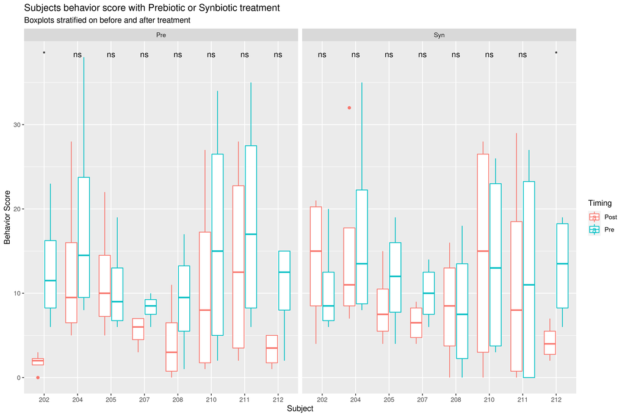

## Behavioral scores of subject “202” and “212”

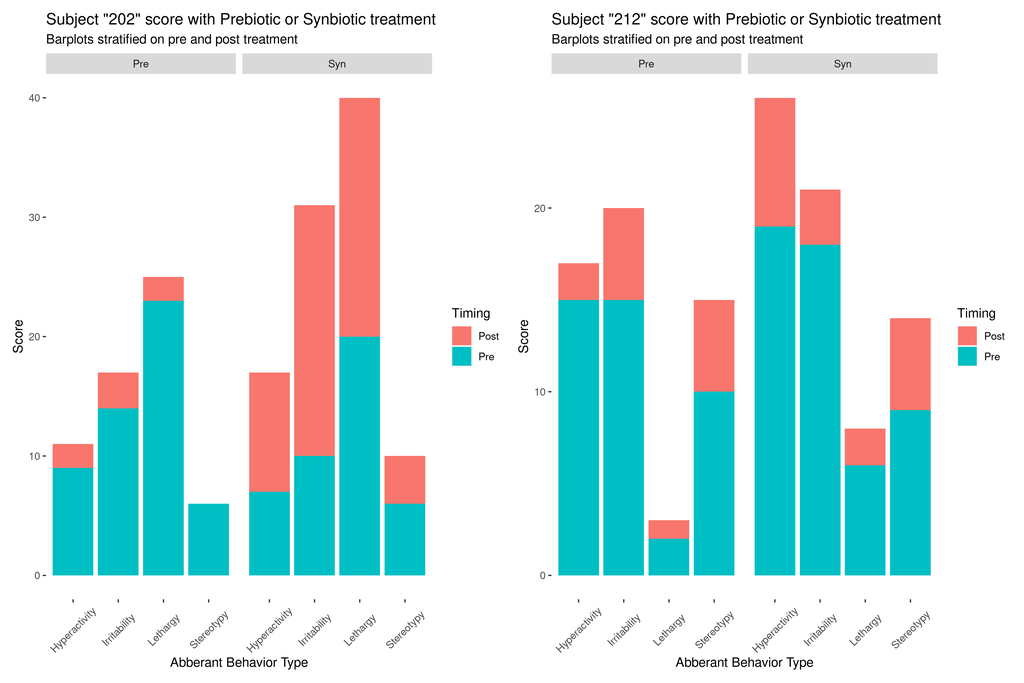

## Gastrointestinal symptoms

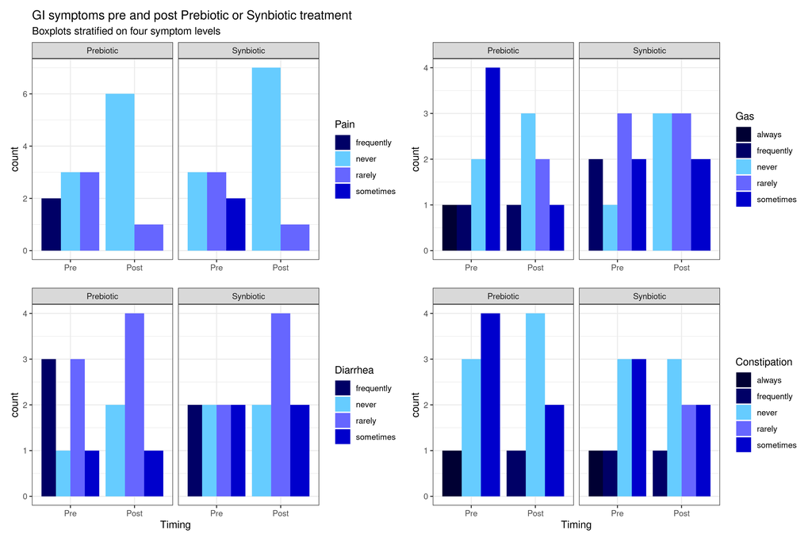

## Microbiome composition

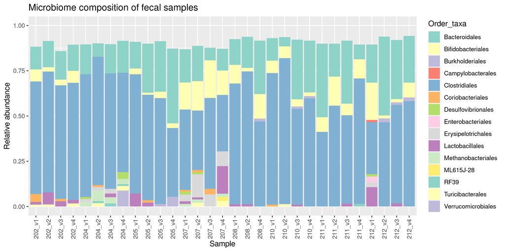

## PCA of microbiomes

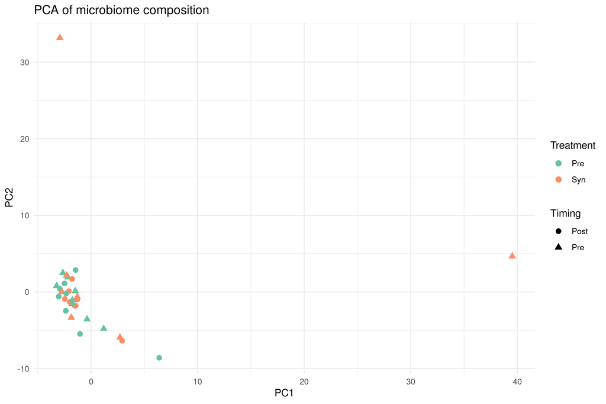

## Aberrant behavior vs. taxa abundance

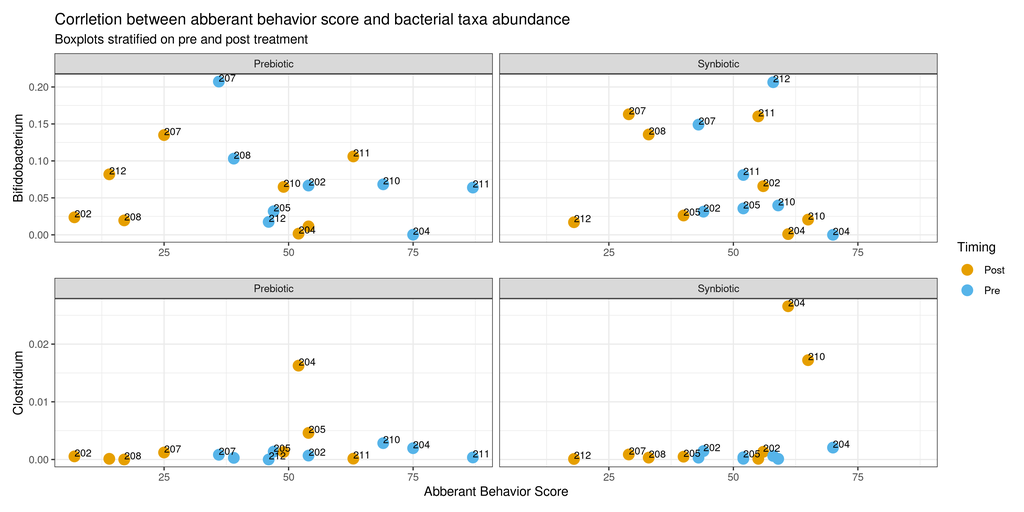

## Gastrointestinal symptoms vs. taxa abundance

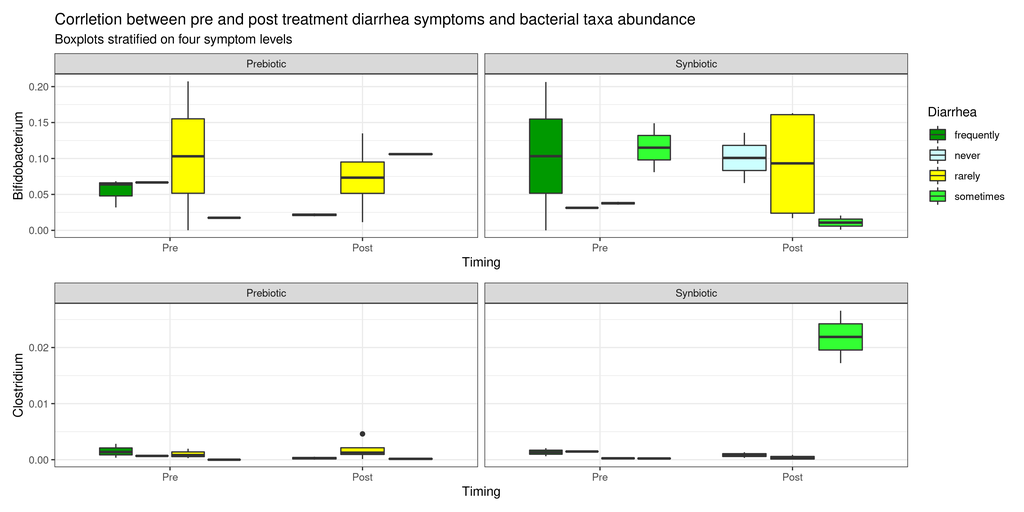

## PCA of metabolome

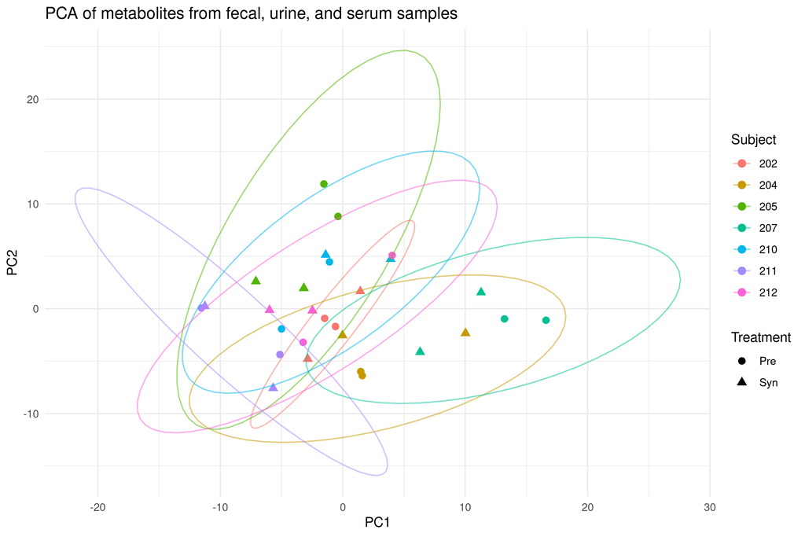

## Correlations of some metabolites and bacterial taxa

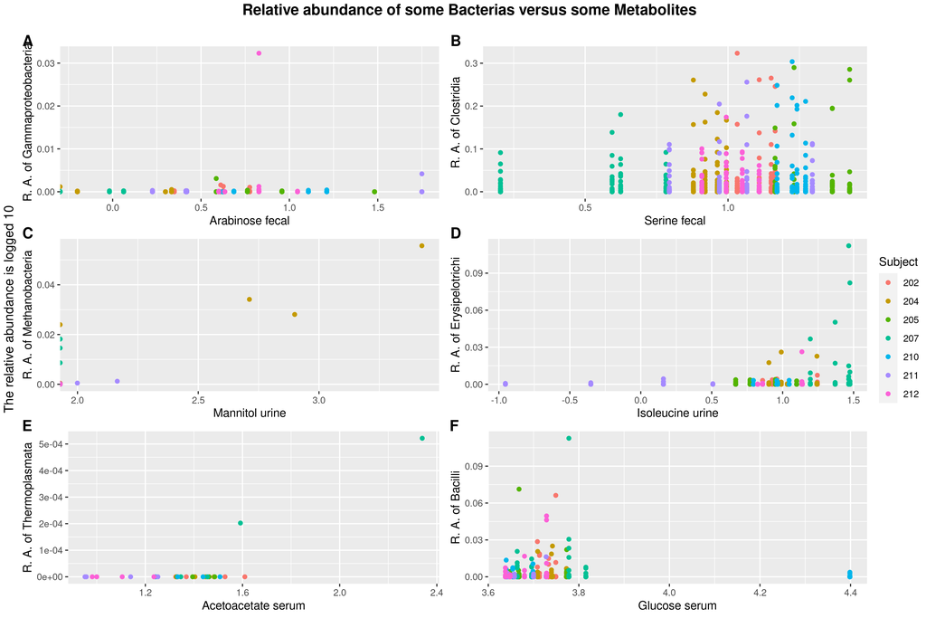

## Immune cell phenotypes

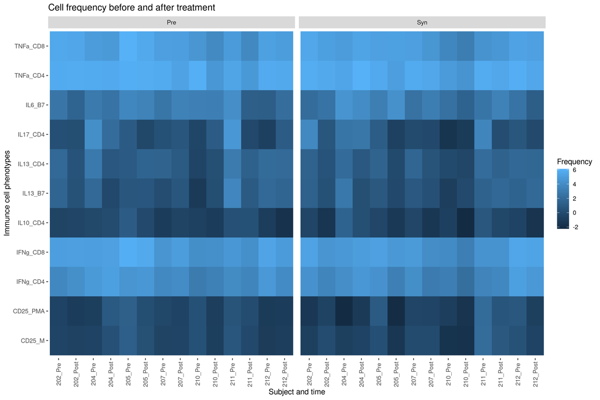

## Immune cells vs. certain metabolites

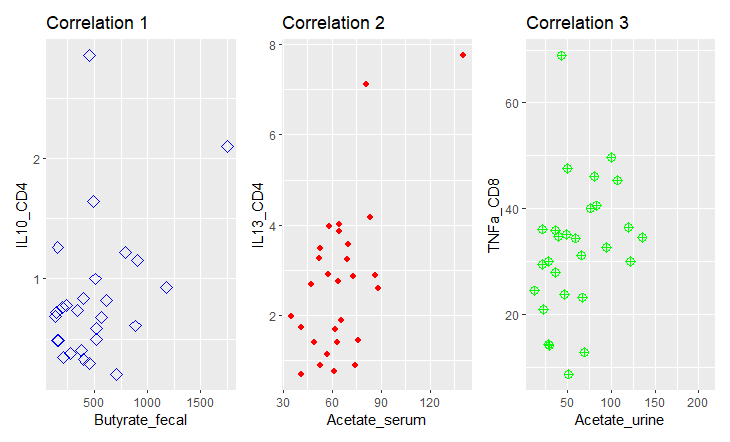

## Discussion

## Discussion

- Improved autism symptoms
- Improved gastrointestinal symptoms

But why?

- Perhaps immune cells (however, subject 202 and 212 do not exhibit marked changes in immune cell phenotypes)
- Perhaps placebo?
- More subjects needed
- Longer test period